# r-primaries

Todd Suomela

October 4, 2016

## Package Setup

Packages to be used and order of attaching

- choroplethr
- choroplethrMaps
- dplyr

```r
library(choroplethr)
library(choroplethrMaps)
library(dplyr)
```

## Data Setup

Two activities are completed in this section. First is attaching county-level data from the choroplethr package. Second is loading the primary data.

1. Attach county-level data from choroplethr
2. Load the data for Pennsylvania into R
3. Add a column to the pa.primaries dataframe that transforms the county name into lowercase. This will be useful later to match the county names in the primary data with the county names in the choroplethr package.
4. create a data frame of pennsylvania counties and FIPS region abbreviations by filtering the county.regions df for state.name == “pennsylvania”

```r
data("county.regions")

pa.primaries <- read.csv("data/Pennsylvania Primary Results by County.csv", header = TRUE)
pa.primaries$county.name <- tolower(pa.primaries$County)

pa.counties <- filter(county.regions, state.name == "pennsylvania")
```

## Plotting Sanders Votes on PA county map

The goal in this section is to create a table that contains two variables: region and value. These two variables can then be passed to county_choropleth and mapped.

region = FIPS code for the counties value = vote total for Sanders in 2016 primary

1. Select to subset just Democratic primary votes and rename columns. This will give us a new table pa.primaries.dem with three columns: county.name, sanders, clinton
2. Create a new table with the Sanders votes and region.
3. Rename sanders variable to value.
4. Execute the choropleth command.

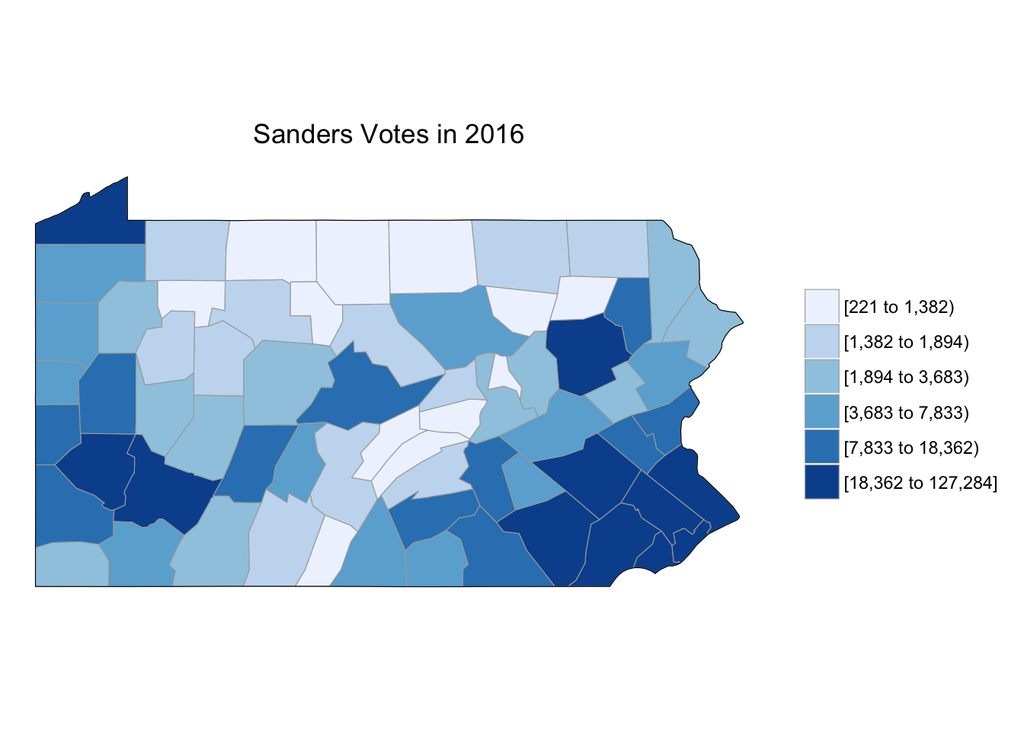

```r
# Filtering the pa.primaries data frame to just the two Democrat candidates, plus renaming the columns.
pa.primaries.dem <- select(pa.primaries, county.name, sanders = Sanders_Bernie, clinton = Clinton_Hillary)

# Combine the county table from choroplethr with the primary data by matching on the lowercase county name.
primaries.sanders <-
  inner_join(pa.counties, pa.primaries.dem, by = "county.name") %>%
  select(region, sanders)

# Rename in order sanders totals to votes.  An extra unneeded step
primaries.sanders <- plyr::rename(primaries.sanders, c("sanders" = "votes"))

# Add a value column in order to fit the expected syntax for the choroplethr package
primaries.sanders$value <- primaries.sanders$votes

county_choropleth(primaries.sanders,
  title = "Sanders Votes in 2016",
  num_colors = 6,
  state_zoom = "pennsylvania")
```

## Improving the plot

Some immediate drawbacks of the plot.

1. The plot as is shows the total number of votes with no account for population of the counties.

Actions

1. Load the “df_county_demographics”" data from the choroplethr package.
2. Merge the demographic data into the primaries.sanders data frame.
3. Rename the variable value to votes.
4. Compute new variable: value, which will be the percent of population voting for Sanders.

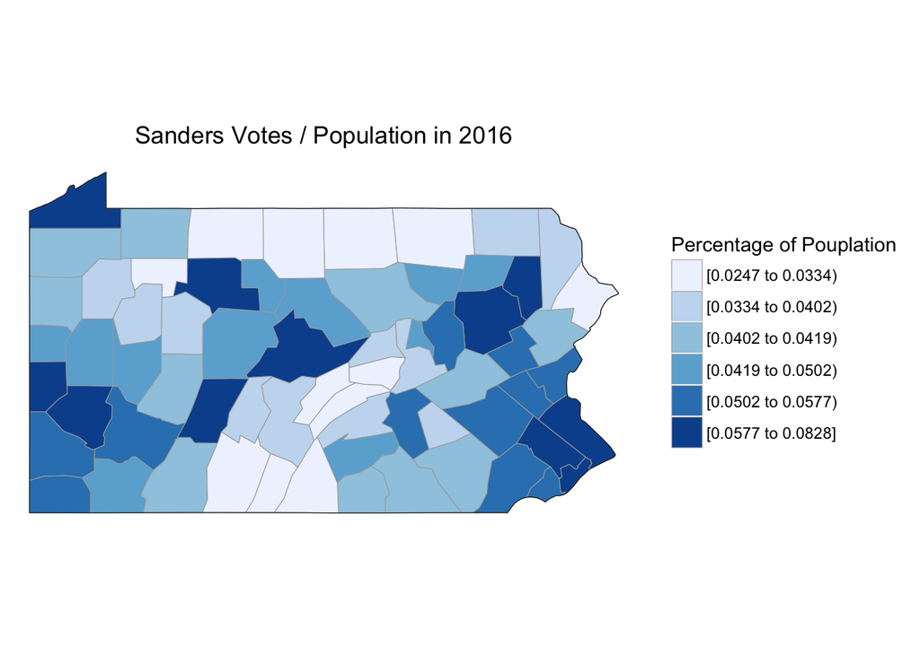

```r
data("df_county_demographics")

primaries.sanders <-
  inner_join(primaries.sanders, df_county_demographics, by = "region")

primaries.sanders$value <-
  primaries.sanders$votes / primaries.sanders$total_population

county_choropleth(primaries.sanders,
  title = "Sanders Votes / Population in 2016",
  legend = "Percentage of Pouplation",
  num_colors = 6,
  state_zoom = "pennsylvania")
```

# Reviewing a linear model for Sanders votes

The primaries.sanders df should contain the following variables: votes, total_population, percent_white, percen_black, percent_asian, percent_hispanic, per_capita_income, median_rent, and median_age.

## The next step is converting the percents to fractions between (0,1)

1. I do the same transformation across all of the race variables. Create a frac_ from the existing percent_
2. Create a frac_vote variable by dividing votes / total_population.

```r
primaries.sanders$frac_white <- primaries.sanders$percent_white / 100
primaries.sanders$frac_black <- primaries.sanders$percent_black / 100
primaries.sanders$frac_asian <- primaries.sanders$percent_asian / 100
primaries.sanders$frac_hispanic <- primaries.sanders$percent_hispanic / 100
primaries.sanders$frac_vote <- primaries.sanders$votes / primaries.sanders$total_population

attach(primaries.sanders)
```

## Creating some linear models

Dependent variable: vote Independent variables: frac_white, frac_black,

```r
fmodel_white_black <- lm(frac_vote ~ frac_white + frac_black)
summary(fmodel_white_black)
```

```
##
## Call:
## lm(formula = frac_vote ~ frac_white + frac_black)
##
## Residuals:
##       Min        1Q    Median        3Q       Max
## -0.025536 -0.007270 -0.000836  0.005731  0.035789
##
## Coefficients:
##              Estimate Std. Error t value Pr(>|t|)
## (Intercept)  0.094942   0.031191   3.044  0.00339 **
## frac_white  -0.056325   0.032545  -1.731  0.08833 .
## frac_black   0.008631   0.052663   0.164  0.87033
## ---
## Signif. codes:  0 '***' 0.001 '**' 0.01 '*' 0.05 '.' 0.1 ' ' 1
##
## Residual standard error: 0.0116 on 64 degrees of freedom
## Multiple R-squared:  0.2249, Adjusted R-squared:  0.2007
## F-statistic: 9.286 on 2 and 64 DF,  p-value: 0.0002878
```

```r
fmodel_races_age <- lm(frac_vote ~ frac_asian + frac_black + frac_hispanic + frac_white)
summary(fmodel_races_age)
```

```
##
## Call:
## lm(formula = frac_vote ~ frac_asian + frac_black + frac_hispanic +
##     frac_white)
##
## Residuals:
##       Min        1Q    Median        3Q       Max
## -0.013977 -0.007929 -0.001001  0.005698  0.031428
##
## Coefficients:
##               Estimate Std. Error t value Pr(>|t|)
## (Intercept)     0.3368     0.1624   2.074   0.0423 *
## frac_asian      0.1532     0.1950   0.786   0.4351
## frac_black     -0.2806     0.1712  -1.639   0.1063
## frac_hispanic  -0.3351     0.1740  -1.926   0.0587 .
## frac_white     -0.3013     0.1644  -1.833   0.0716 .
## ---
## Signif. codes:  0 '***' 0.001 '**' 0.01 '*' 0.05 '.' 0.1 ' ' 1
##
## Residual standard error: 0.01033 on 62 degrees of freedom
## Multiple R-squared:  0.405,  Adjusted R-squared:  0.3666
## F-statistic: 10.55 on 4 and 62 DF,  p-value: 1.388e-06
```

```r
fmodel_age_white <- lm(frac_vote ~ frac_white + median_age)
summary(fmodel_age_white)
```

```
##
## Call:
## lm(formula = frac_vote ~ frac_white + median_age)
##
## Residuals:
##       Min        1Q    Median        3Q       Max
## -0.024832 -0.007206 -0.001282  0.006063  0.035588
##
## Coefficients:
##               Estimate Std. Error t value Pr(>|t|)
## (Intercept)  0.1027292  0.0197060   5.213 2.12e-06 ***
## frac_white  -0.0592302  0.0168562  -3.514 0.000816 ***
## median_age  -0.0001147  0.0005504  -0.208 0.835641
## ---
## Signif. codes:  0 '***' 0.001 '**' 0.01 '*' 0.05 '.' 0.1 ' ' 1
##
## Residual standard error: 0.0116 on 64 degrees of freedom
## Multiple R-squared:  0.2251, Adjusted R-squared:  0.2009
## F-statistic: 9.297 on 2 and 64 DF,  p-value: 0.0002854
```

```r
fmodel_complete <- lm(frac_vote ~ per_capita_income + median_rent + median_age + frac_white + frac_black + frac_asian + frac_hispanic)
summary(fmodel_complete)
```

```
##
## Call:
## lm(formula = frac_vote ~ per_capita_income + median_rent + median_age +
##     frac_white + frac_black + frac_asian + frac_hispanic)
##
## Residuals:
##       Min        1Q    Median        3Q       Max
## -0.014677 -0.006436 -0.001513  0.006479  0.025125
##
## Coefficients:
##                     Estimate Std. Error t value Pr(>|t|)
## (Intercept)        4.128e-01  1.621e-01   2.547  0.01350 *
## per_capita_income  1.110e-06  6.507e-07   1.705  0.09337 .
## median_rent       -7.758e-05  2.274e-05  -3.411  0.00117 **
## median_age         4.927e-05  5.650e-04   0.087  0.93079
## frac_white        -3.722e-01  1.617e-01  -2.301  0.02492 *
## frac_black        -3.669e-01  1.743e-01  -2.105  0.03959 *
## frac_asian         4.027e-01  2.199e-01   1.831  0.07214 .
## frac_hispanic     -3.080e-01  1.698e-01  -1.814  0.07483 .
## ---
## Signif. codes:  0 '***' 0.001 '**' 0.01 '*' 0.05 '.' 0.1 ' ' 1
##
## Residual standard error: 0.009572 on 59 degrees of freedom
## Multiple R-squared:  0.5137, Adjusted R-squared:  0.456
## F-statistic: 8.903 on 7 and 59 DF,  p-value: 1.948e-07
```